# Odontoblast growth - Vitamin C

Lovdip Singh

## Questions of Interest

We are primarily interested in if tooth growth (as measured by the size of odontoblasts) increases as the dose of vitamin C increases. Also, does any increase depend on the delivery method?

## Read in and inspect the data:

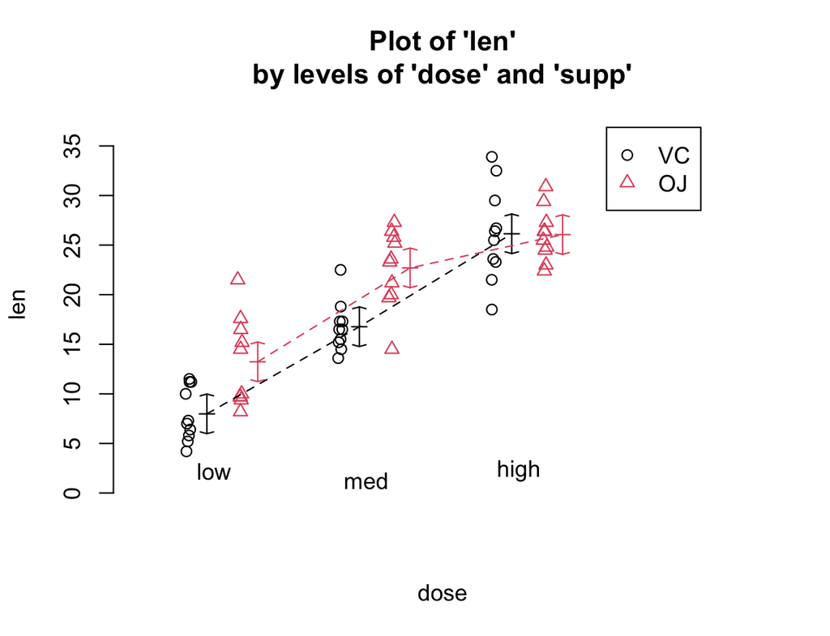

```r
Tooth.df=read.csv("Tooth.csv")
Tooth.df$supp=as.factor(Tooth.df$supp)
Tooth.df$dose=as.factor(Tooth.df$dose)
interactionPlots(len~dose+supp,data=Tooth.df)
```

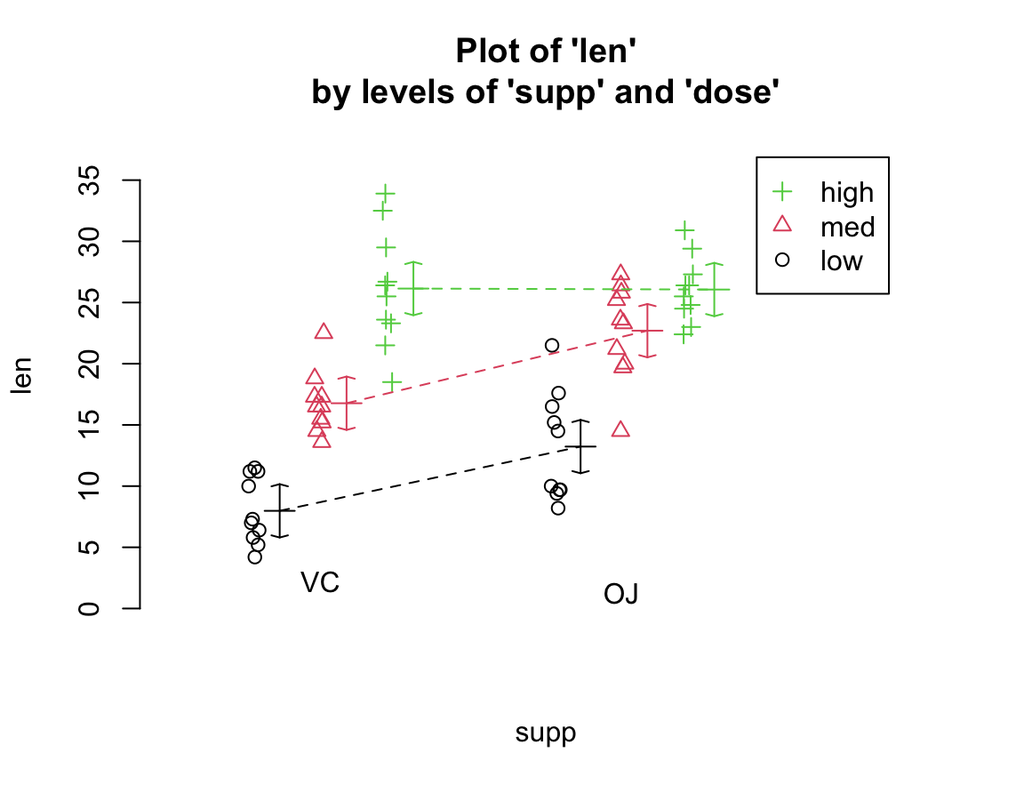

```r
interactionPlots(len~supp+dose,data=Tooth.df)
```

Higher doses of VC appear to increase the size of odontoblasts, there is no overlap between the intervals between the doses for VC. As the dose of OJ increases from low to med the mean length of odontoblast also increases with no overlap between the two intervals, however there appears to be a bit of overlap between the mean interval for length of odontoblast between med and high doses of OJ. The mean odontoblast lengths for low dose appears to be higher for OJ compared to VC. For medium dose, the mean appears to be higher for OJ compared to VC with no overlap between the intervals, for high dose, there does not seem to be a difference between the means of odontoblasts for VC or OJ for high dose.

## Model fitting

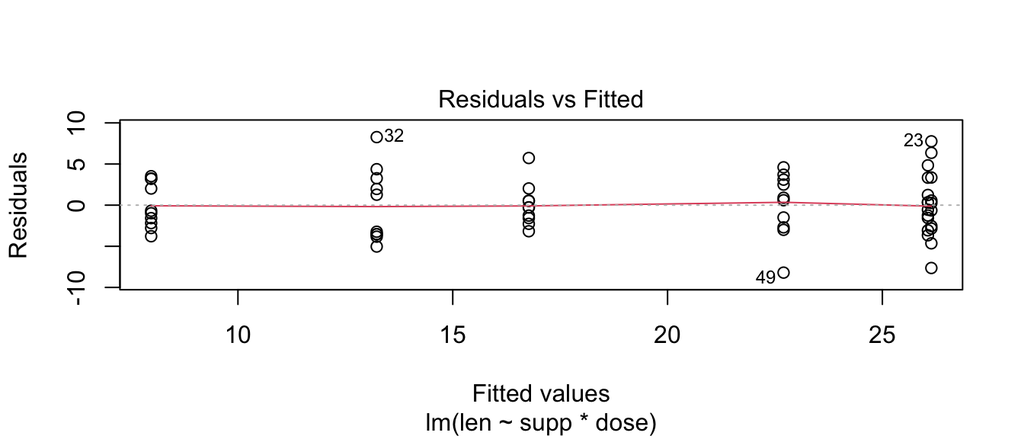

```r
tooth.fit <- lm(len~supp*dose, data=Tooth.df)
plot(tooth.fit, which=1)
```

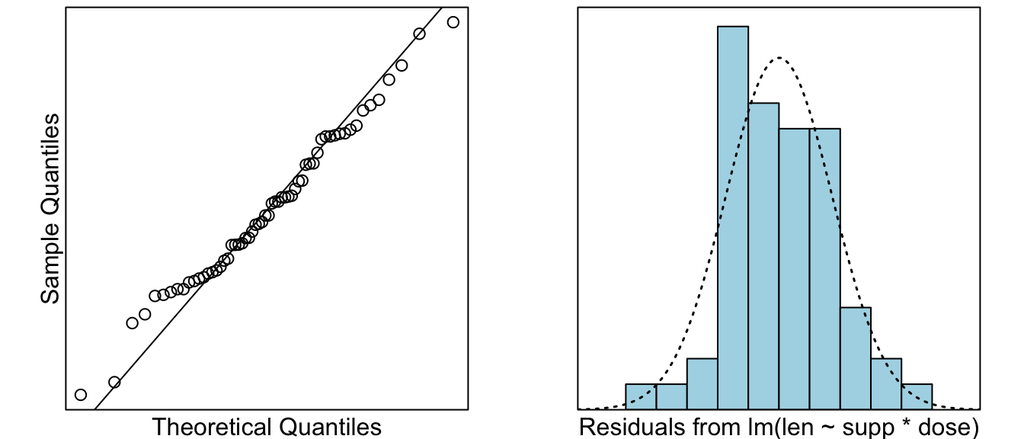

```r
normcheck(tooth.fit)
```

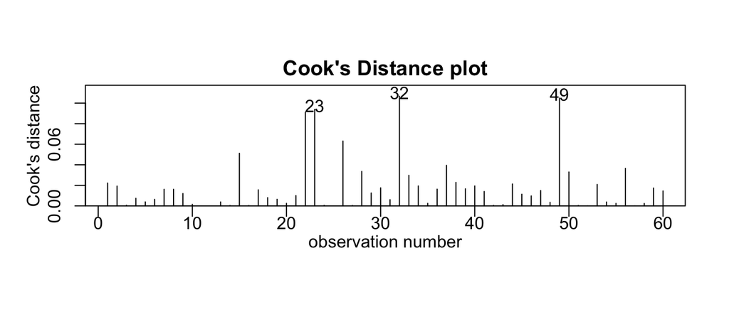

```r
cooks20x(tooth.fit)
```

```r
anova(tooth.fit)
```

```
## Analysis of Variance Table
##
## Response: len
##           Df  Sum Sq Mean Sq F value    Pr(>F)
## supp       1  205.35  205.35  15.572 0.0002312 ***
## dose       2 2426.43 1213.22  92.000 < 2.2e-16 ***
## supp:dose  2  108.32   54.16   4.107 0.0218603 *
## Residuals 54  712.11   13.19
## ---
## Signif. codes:  0 '***' 0.001 '**' 0.01 '*' 0.05 '.' 0.1 ' ' 1
```

```r
summary(tooth.fit)
```

```
##
## Call:
## lm(formula = len ~ supp * dose, data = Tooth.df)
##
## Residuals:
##    Min     1Q Median     3Q    Max
##  -8.20  -2.72  -0.27   2.65   8.27
##
## Coefficients:
##                Estimate Std. Error t value Pr(>|t|)
## (Intercept)      26.060      1.148  22.693  < 2e-16 ***
## suppVC            0.080      1.624   0.049   0.9609
## doselow         -12.830      1.624  -7.900 1.43e-10 ***
## dosemed          -3.360      1.624  -2.069   0.0434 *
## suppVC:doselow   -5.330      2.297  -2.321   0.0241 *
## suppVC:dosemed   -6.010      2.297  -2.617   0.0115 *
## ---
## Signif. codes:  0 '***' 0.001 '**' 0.01 '*' 0.05 '.' 0.1 ' ' 1
##
## Residual standard error: 3.631 on 54 degrees of freedom
## Multiple R-squared:  0.7937, Adjusted R-squared:  0.7746
## F-statistic: 41.56 on 5 and 54 DF,  p-value: < 2.2e-16
```

```r
summary2way(tooth.fit, page="interaction")
```

```
##   Tukey multiple comparisons of means
##     95% family-wise confidence level
##
## Fit: aov(formula = fit)
##
## $`Comparisons within c("supp", "dose")`
##                  diff        lwr        upr     p adj
## OJ:low-OJ:high -12.83 -17.628124  -8.031876 0.0000000
## OJ:med-OJ:high  -3.36  -8.158124   1.438124 0.3187361
## VC:low-VC:high -18.16 -22.958124 -13.361876 0.0000000
## VC:med-VC:high  -9.37 -14.168124  -4.571876 0.0000058
## OJ:med-OJ:low    9.47   4.671876  14.268124 0.0000046
## VC:med-VC:low    8.79   3.991876  13.588124 0.0000210
##
## $`Comparisons between c("supp", "dose")`
##                  diff        lwr        upr     p adj
## VC:high-OJ:high  0.08  -4.718124  4.8781238 1.0000000
## VC:low-OJ:low   -5.25 -10.048124 -0.4518762 0.0242521
## VC:med-OJ:med   -5.93 -10.728124 -1.1318762 0.0073930
```

## Method and Assumption Checks

We have two explanatory variables, supplement and dose, and one numeric response length of odontoblast. The interaction plots suggests an interaction between supplement (vitamin C or orange juice) and dose (low, medium, high). So a two-way ANOVA model with interaction between supplement and dose was fitted. The interaction term was significant, with a $P\text{-}value = 0.0219$. The assumption were reasonable, the normality assumption was not necessarily with this model, and as a result we may get biased confidence intervals. There were no unduly influential points.

Our final model is

$$Length_i= \beta_0 + \beta_1 \times Supp.Vc_i + \beta_2 \times Dose.Low_i + \beta_3 \times Dose.Med_i + \beta_4 \times Supp.Vc_i \times Dose.Low_i + \beta_5 \times Supp.Vc_i \times Dose.Med_i + \epsilon_i$$

Where $Supp.Vc_i$, $Dose.Med_i$ and $Dose.Low_i$ are dummy variables the take the value 1 if the guinea pigs were given vitamin C tablet, had a medium dosage of supplement, had a low dosage of supplement respectively, otherwise they are $0$, and $\epsilon_i \sim iid N(0, \sigma^2)$

Our model explained 79% of the variability in the guinea pigs’ odontoblast lengths.

## Executive Summary

We were interested if tooth growth increases as the dose of vitamin C increases.

We estimate for those guinea pigs taking vitamin C tablets, a medium dose increases the length of odontoblasts by between 4.0 to 13.6 micrometers, compared to those taking a low dose. Furthoremore, a high dose increases the length by between 4.6 to 14.2 micrometers, compared to medium dose of vitamin C tablets.

We estimate for those guinea pigs taking orange juice, a medium dose increases the length of odonotoblasts by between 4.7 to 14.3 micrometers, compared to low dose. No significant difference was found between the high and medium doses of vitamin C via orange juice with regards to length of odonotblasts.

We estimate that for guinea pigs taking a low dose of vitamin c via orange juice, their odontoblast length is between 0.5 to 10.0 micrometers greater than guinea pigs taking a low dose of vitamin c via tablets.

We estimate that for guinea pigs taking a medium dose of vitamin c via orange juice, their odontoblast length is between 1.1 to 10.7 micrometers greater than guinea pigs taking a medium dose of vitamin c via tablets.

No significant difference was found between the length of odontoblasts of guinea pigs for those that took a high dose of vitamin c via tablet and a high dose via orange juice.

### Which single combination tends to lead to the lowest length odontoblasts?

A low dose of vitamin C via tablets.

### Which single combination tends to lead to the highest length odontoblasts?

No, there is no significant difference between medium and high doses of vitamin C via orange juice, and between high doses of vitamin C in orange juice compared to high dose of vitamin c via tablets for odontoblast length. This means we cannot say which single combination of supplement and dose leads to the highest length of odontoblast in guinea pigs.

### Assuming we want to use as small a dose level as possible, what dose level gives the highest length of odontoblasts for guinea pigs given orange juice?

Medium dose, as there is no significant difference between medium dose orange juice and high dose orange juice for odontoblast length, but there is an increase in odontoblast length for medium dose compared to low dose vitamin c via orange juice.

### Assuming we want to use as small a dose level as possible, what dose level gives the highest length of odontoblasts for guinea pigs given vitamin C tablets?

High dose of vitamin C tablet. A high dose of vitamin C via tablet leads to a statistically significant greater odontoblast length on average, compared to both medium and low doses of vitamin C via tablet for guinea pigs.